# tSNR across days and echoes

Benjamin Meyer

13 September 2026

## Read the data

The file is comma-separated: column 1 is the subject ID, the remaining columns are tSNR values named `r<run>e<echo>` (R = resting-state scan, E = echo). `NaN` entries (runs/echoes missing for a subject) are read as `NA`.

```r
tsnr <- read.csv(
  "tSNR_results.txt",
  header     = TRUE,
  na.strings = c("NA", "NaN", "")
)

names(tsnr)[1] <- "ID"
value_cols <- setdiff(names(tsnr), "ID")

str(tsnr)
```

```
## 'data.frame':    25 obs. of  25 variables:
##  $ ID  : chr  "sub-10" "sub-11" "sub-12" "sub-13" ...
##  $ r1e1: num  90 78.2 91 80.3 76.4 ...
##  $ r1e2: num  61.5 53.5 62.2 55.6 49.8 ...
##  $ r1e3: num  43.4 37.6 44 39.8 34.9 ...
##  $ r1e4: num  31.5 27 32.2 29 25.4 ...
##  $ r2e1: num  74.9 76.9 80.5 79.8 55.4 ...
##  $ r2e2: num  51.4 52.7 56.8 56 37.5 ...
##  $ r2e3: num  36.2 37.2 40.8 40 26.8 ...
##  $ r2e4: num  26.1 26.7 29.5 28.7 19.6 ...
##  $ r3e1: num  72.7 78 83.2 79.8 70.2 ...
##  $ r3e2: num  49.7 53.3 58.8 55.7 46.6 ...
##  $ r3e3: num  35 37.7 42.6 39.7 32.9 ...
##  $ r3e4: num  25.2 27.1 30.8 28.4 23.7 ...
##  $ r4e1: num  80.9 78.7 79.4 73.4 73.2 ...
##  $ r4e2: num  57 54.2 54.8 51.3 48.6 ...
##  $ r4e3: num  41 38.2 39 36.3 34.4 ...
##  $ r4e4: num  29.8 27.4 28.2 26 24.9 ...
##  $ r5e1: num  78.8 79.2 82.1 70.1 74.5 ...
##  $ r5e2: num  55.2 54.6 57 48.8 50.2 ...
##  $ r5e3: num  39.4 38.7 40.7 34.6 35.6 ...
##  $ r5e4: num  28.5 27.7 29.5 24.9 25.7 ...
##  $ r6e1: num  84.7 85.6 83.2 77.5 67.7 ...
##  $ r6e2: num  57.2 59.8 56.9 53.5 43.9 ...
##  $ r6e3: num  39.9 42.7 40.8 37.8 30.9 ...
##  $ r6e4: num  28.8 30.9 29.9 27.1 22.4 ...
```

## Reshape to long format

`run` and `echo` are pulled out of the column names.

```r
tsnr_long <- tsnr |>
  pivot_longer(
    cols      = all_of(value_cols),
    names_to  = "scan",
    values_to = "tSNR"
  ) |>
  mutate(
    scan = factor(scan, levels = value_cols),
    run  = as.integer(sub("^r(\\d+)e\\d+$", "\\1", scan)),
    echo = factor(as.integer(sub("^r\\d+e(\\d+)$", "\\1", scan)))
  ) |>
  filter(!is.na(tSNR))

head(tsnr_long)
```

| ID | scan | tSNR | run | echo |
| --- | --- | --- | --- | --- |
| sub-10 | r1e1 | 90.03852 | 1 | 1 |
| sub-10 | r1e2 | 61.51812 | 1 | 2 |
| sub-10 | r1e3 | 43.43831 | 1 | 3 |
| sub-10 | r1e4 | 31.45009 | 1 | 4 |
| sub-10 | r2e1 | 74.94011 | 2 | 1 |
| sub-10 | r2e2 | 51.42951 | 2 | 2 |

## Run-to-day mapping

Taken from the acquisition loop in the data-generating scripts (`eeg_fmri_ext_SNR_1_v2.m:63` and `eeg_fmri_ext_SNR_2_v2.sh:61`, both `rest_day = [1 2 2 2 2 3]`), with the EEG status from `eeg_fmri_ext_SNR_1_v2.m:62` (“1, 6: without EEG; 2, 3, 4, 5: with EEG”):

| Run | Session | EEG |
| --- | --- | --- |
| 1 | `ses-Day1_task-rest1` | no |
| 2 | `ses-Day2_task-rest2` | **yes** |
| 3 | `ses-Day2_task-rest3` | **yes** |
| 4 | `ses-Day2_task-rest4` | **yes** |
| 5 | `ses-Day2_task-rest5` | **yes** |
| 6 | `ses-Day3_task-rest6` | no |

Two questions follow from this, and they are analysed separately below:

1. **Across days** — runs 1, 2 and 6, i.e. the first resting-state scan of each day, one run per day. This is the session-stability question.
2. **Within Day 2** — runs 2 to 5, the four EEG runs of the middle session. This asks whether tSNR drifts over the course of the EEG session.

## Helpers: plotting and significance annotation

Both analyses produce the same kind of figure (echo blocks on the x-axis, the grouping factor within each block) and the same kind of post-hoc table, so the plot and the significance brackets are written once here and reused.

Brackets are drawn only for the **within-echo** comparisons that survive Holm correction: `***` *p* < .001, `**` *p* < .01, `*` *p* < .05. Non-significant comparisons are left unmarked. Each bracket sits just above the data of its own echo block rather than at a single panel-wide height — echo 1 has roughly three times the tSNR of echo 4, so one common height would strand the echo-4 brackets far above their boxes.

```r
p_stars <- function(p) {
  ifelse(p < 0.001, "***",
  ifelse(p < 0.01,  "**",
  ifelse(p < 0.05,  "*", NA_character_)))
}

# Lowest free vertical tier per bracket, so that overlapping spans stack
# instead of being drawn on top of each other.
pack_tiers <- function(xmin, xmax, pad = 0.35) {
  tier <- integer(length(xmin))
  for (i in seq_along(xmin)) {
    j <- seq_len(i - 1L)
    t <- 1L
    while (any(tier[j] == t & xmin[i] <= xmax[j] + pad & xmax[i] >= xmin[j] - pad)) {
      t <- t + 1L
    }
    tier[i] <- t
  }
  tier
}

# x-axis cells: one box per echo x group combination, ordered echo-major so the
# groups being compared sit next to each other.
add_cells <- function(d) {
  d   <- d |> mutate(echo = droplevels(echo), grp = droplevels(grp))
  lev <- paste0(rep(levels(d$echo), each = nlevels(d$grp)), "_", levels(d$grp))
  d |> mutate(
    cell = factor(paste0(as.character(echo), "_", as.character(grp)), levels = lev)
  )
}

# pw: within-echo pairwise table with columns echo, group1, group2, p.adj.
# Returns a list of layers, empty if nothing is significant.
sig_geom <- function(pw, d, step_frac = 0.055, tick_frac = 0.014) {
  grp  <- levels(d$grp)
  span <- diff(range(d$tSNR))
  step <- step_frac * span
  tick <- tick_frac * span

  y_echo <- d |>
    group_by(echo) |>
    summarise(y0 = max(tSNR), .groups = "drop") |>
    mutate(echo = as.character(echo))

  b <- pw |>
    ungroup() |>
    mutate(label = p_stars(p.adj), echo = as.character(echo)) |>
    filter(!is.na(label)) |>
    mutate(
      e    = match(echo, levels(d$echo)),
      xmin = (e - 1) * length(grp) + pmin(match(group1, grp), match(group2, grp)),
      xmax = (e - 1) * length(grp) + pmax(match(group1, grp), match(group2, grp))
    ) |>
    left_join(y_echo, by = "echo") |>
    arrange(e, xmax - xmin, xmin) |>
    group_by(e) |>
    mutate(tier = pack_tiers(xmin, xmax)) |>
    ungroup() |>
    mutate(y = y0 + tier * step)

  if (nrow(b) == 0) return(list())

  # Four points per bracket: down-tick, across, down-tick.
  paths <- data.frame(
    id = rep(seq_len(nrow(b)), each = 4),
    x  = as.vector(rbind(b$xmin, b$xmin, b$xmax, b$xmax)),
    y  = as.vector(rbind(b$y - tick, b$y, b$y, b$y - tick))
  )

  list(
    geom_path(
      data = paths, aes(x = x, y = y, group = id),
      colour = "black", linewidth = 0.4, inherit.aes = FALSE
    ),
    geom_text(
      data = b, aes(x = (xmin + xmax) / 2, y = y, label = label),
      vjust = -0.15, size = 4.6, colour = "black", inherit.aes = FALSE
    ),
    expand_limits(y = max(b$y) + 1.8 * step)
  )
}
```

Black boxes and points, no background grid, explicit x- and y-axis lines, and `base_size = 14` so the figure stays legible at A4 width. The x-axis is two-tiered: the grouping factor on the axis itself, echo beneath.

```r
base_font <- 14   # readable when the 8 x 5.5 in figure is placed on A4

theme_tsnr <- theme_classic(base_size = base_font) +
  theme(
    panel.grid       = element_blank(),
    axis.line        = element_line(colour = "black", linewidth = 0.5),
    axis.ticks       = element_line(colour = "black", linewidth = 0.5),
    axis.text        = element_text(colour = "black"),
    axis.title       = element_text(colour = "black"),
    axis.title.x     = element_text(margin = margin(t = 30)),
    axis.title.y     = element_text(margin = margin(r = 8)),
    plot.title       = element_text(face = "bold", size = base_font + 1),
    plot.subtitle    = element_text(size = base_font - 2),
    plot.caption     = element_text(size = base_font - 3, hjust = 0, colour = "grey30"),
    plot.margin      = margin(6, 8, 14, 6)
  )

theme_set(theme_tsnr)
```

```r
tsnr_panel <- function(d, pw = NULL, title, subtitle, caption, x_title,
                       short = identity) {
  n_g <- nlevels(d$grp)

  # One label per echo, centred under that echo's block of boxes.
  echo_tier <- data.frame(
    x     = (seq_len(nlevels(d$echo)) - 1) * n_g + (n_g + 1) / 2,
    label = paste0("Echo ", levels(d$echo))
  )

  # Jitter is horizontal only, so no point is drawn at a false tSNR value.
  p <- ggplot(d, aes(x = cell, y = tSNR)) +
    geom_boxplot(
      fill = "white", colour = "black",
      linewidth = 0.5, width = 0.62,
      outlier.shape = NA          # outliers are already shown as points below
    ) +
    geom_point(
      position = position_jitter(width = 0.16, height = 0, seed = 42),
      shape = 21, fill = "black", colour = "white",
      size = 2.1, stroke = 0.35, alpha = 0.9
    ) +
    geom_text(
      data = echo_tier, aes(x = x, y = -Inf, label = label),
      vjust = 3.5, size = base_font / .pt, colour = "black",
      inherit.aes = FALSE
    ) +
    scale_x_discrete(labels = \(z) short(sub("^[^_]+_", "", z))) +
    scale_y_continuous(expand = expansion(mult = c(0.04, 0.06))) +
    coord_cartesian(clip = "off") +
    labs(
      title = title, subtitle = subtitle, caption = caption,
      x = x_title, y = "tSNR (grey matter)"
    )

  if (!is.null(pw)) p <- p + sig_geom(pw, d)
  p
}
```

# Part 1: across days (runs 1, 2, 6)

```r
runs_keep <- c(1, 2, 6)
day_labels <- c("Day 1", "Day 2", "Day 3")

tsnr_day <- tsnr_long |>
  filter(run %in% runs_keep) |>
  mutate(
    day  = factor(run, levels = runs_keep, labels = day_labels),
    scan = droplevels(scan),
    echo = droplevels(echo)
  )

# The ANOVA is a fully within-subject design, so it needs subjects with a value
# in every day x echo cell.
n_cells <- length(runs_keep) * nlevels(tsnr_day$echo)

tsnr_rm <- tsnr_day |>
  group_by(ID) |>
  filter(dplyr::n() == n_cells) |>
  ungroup() |>
  mutate(ID = factor(ID), grp = day) |>
  add_cells()

cat(
  "Complete cases: ", n_distinct(tsnr_rm$ID), " of ",
  n_distinct(tsnr_day$ID), " subjects\n", sep = ""
)
```

```
## Complete cases: 21 of 25 subjects
```

Subjects excluded, and which of the three runs they have:

```r
tsnr_day |>
  group_by(ID) |>
  filter(dplyr::n() < n_cells) |>
  summarise(runs_present = paste(sort(unique(run)), collapse = ", "), .groups = "drop")
```

| ID | runs_present |
| --- | --- |
| sub-16 | 1 |
| sub-20 | 1, 2 |
| sub-25 | 2, 6 |
| sub-28 | 1, 2 |

## Summary statistics

```r
tsnr_rm |>
  group_by(echo, day) |>
  summarise(
    n      = dplyr::n(),
    mean   = mean(tSNR),
    sd     = sd(tSNR),
    median = median(tSNR),
    IQR    = IQR(tSNR),
    min    = min(tSNR),
    max    = max(tSNR),
    .groups = "drop"
  ) |>
  mutate(across(mean:max, ~ round(.x, 2)))
```

| echo | day | n | mean | sd | median | IQR | min | max |
| --- | --- | --- | --- | --- | --- | --- | --- | --- |
| 1 | Day 1 | 21 | 82.34 | 6.90 | 82.70 | 8.40 | 64.80 | 93.38 |
| 1 | Day 2 | 21 | 76.39 | 7.03 | 78.28 | 6.04 | 55.38 | 84.16 |
| 1 | Day 3 | 21 | 81.46 | 7.47 | 83.22 | 7.78 | 66.99 | 95.93 |
| 2 | Day 1 | 21 | 56.26 | 4.67 | 55.61 | 6.38 | 46.38 | 65.25 |
| 2 | Day 2 | 21 | 52.96 | 5.14 | 54.01 | 5.40 | 37.54 | 58.58 |
| 2 | Day 3 | 21 | 55.95 | 5.64 | 56.44 | 6.05 | 43.94 | 66.28 |
| 3 | Day 1 | 21 | 39.91 | 3.47 | 39.53 | 4.57 | 33.23 | 47.18 |
| 3 | Day 2 | 21 | 37.76 | 3.83 | 38.76 | 3.96 | 26.75 | 42.90 |
| 3 | Day 3 | 21 | 39.87 | 4.24 | 40.25 | 3.84 | 30.93 | 47.97 |
| 4 | Day 1 | 21 | 28.97 | 2.63 | 28.96 | 3.49 | 24.26 | 34.68 |

[output cut: 2 more lines]

## Two-way repeated-measures ANOVA

Every subject contributes a value in all 12 cells, so **day** (3 levels) and **echo** (4 levels) are both within-subject factors. One ANOVA, with both main effects and their interaction. Greenhouse-Geisser is applied automatically where Mauchly’s test indicates a sphericity violation; `ges` is generalised eta-squared.

```r
fit <- anova_test(tsnr_rm, dv = tSNR, wid = ID, within = c(day, echo))

get_anova_table(fit, correction = "auto")
```

|  | Effect | DFn | DFd | F | p | p<.05 | ges |
| --- | --- | --- | --- | --- | --- | --- | --- |
| 1 | day | 2.00 | 40.00 | 6.802 | 3.00e-03 | * | 0.083 |
| 2 | echo | 1.07 | 21.31 | 3427.887 | 2.90e-25 | * | 0.940 |
| 3 | day:echo | 2.16 | 43.16 | 11.712 | 5.92e-05 | * | 0.021 |

Sphericity:

```r
fit$`Mauchly's Test for Sphericity`
```

|  | Effect | W | p | p<.05 |
| --- | --- | --- | --- | --- |
| 1 | day | 9.57e-01 | 6.57e-01 |  |
| 2 | echo | 1.00e-03 | 6.31e-26 | * |
| 3 | day:echo | 3.45e-07 | 8.48e-44 | * |

```r
fit$`Sphericity Corrections`
```

| Effect | GGe | DF[GG] | p[GG] | p[GG]<.05 | HFe | DF[HF] | p[HF] | p[HF]<.05 |
| --- | --- | --- | --- | --- | --- | --- | --- | --- |
| day | 0.959 | 1.92, 38.34 | 3.00e-03 | * | 1.058 | 2.12, 42.32 | 3.00e-03 | * |
| echo | 0.355 | 1.07, 21.31 | 2.90e-25 | * | 0.359 | 1.08, 21.52 | 1.71e-25 | * |
| day:echo | 0.360 | 2.16, 43.16 | 5.92e-05 | * | 0.405 | 2.43, 48.55 | 2.46e-05 | * |

### Marginal means

```r
tsnr_rm |>
  group_by(day) |>
  summarise(mean = round(mean(tSNR), 2), sd = round(sd(tSNR), 2), .groups = "drop")
```

| day | mean | sd |
| --- | --- | --- |
| Day 1 | 51.87 | 20.74 |
| Day 2 | 48.61 | 19.19 |
| Day 3 | 51.56 | 20.56 |

```r
tsnr_rm |>
  group_by(echo) |>
  summarise(mean = round(mean(tSNR), 2), sd = round(sd(tSNR), 2), .groups = "drop")
```

| echo | mean | sd |
| --- | --- | --- |
| 1 | 80.07 | 7.50 |
| 2 | 55.06 | 5.30 |
| 3 | 39.18 | 3.93 |
| 4 | 28.41 | 2.92 |

### Post-hoc comparisons

Paired *t*-tests between days, Holm-corrected. First as a follow-up to the day main effect, then within each echo as a follow-up to the interaction.

For the main-effect follow-up the four echoes of a subject are averaged into one value per subject and day *before* the test. Testing the un-averaged rows would treat each echo as an independent replicate and give *df* = 83 instead of 20, which inflates the *t* statistics.

```r
day_posthoc <- tsnr_rm |>
  group_by(ID, day) |>
  summarise(tSNR = mean(tSNR), .groups = "drop") |>
  pairwise_t_test(tSNR ~ day, paired = TRUE, p.adjust.method = "holm")

day_posthoc |>
  select(group1, group2, statistic, df, p, p.adj, p.adj.signif)
```

| group1 | group2 | statistic | df | p | p.adj | p.adj.signif |
| --- | --- | --- | --- | --- | --- | --- |
| Day 1 | Day 2 | 3.6886877 | 20 | 0.001 | 0.004 | ** |
| Day 1 | Day 3 | 0.2902949 | 20 | 0.775 | 0.775 | ns |
| Day 2 | Day 3 | -3.0252098 | 20 | 0.007 | 0.013 | * |

Within each echo — these are the comparisons annotated on the figure:

```r
day_by_echo <- tsnr_rm |>
  group_by(echo) |>
  pairwise_t_test(tSNR ~ day, paired = TRUE, p.adjust.method = "holm")

day_by_echo |>
  select(echo, group1, group2, statistic, df, p, p.adj, p.adj.signif)
```

| echo | group1 | group2 | statistic | df | p | p.adj | p.adj.signif |
| --- | --- | --- | --- | --- | --- | --- | --- |
| 1 | Day 1 | Day 2 | 4.33346750 | 20 | 0.000323 | 0.000969 | *** |
| 1 | Day 1 | Day 3 | 0.57806046 | 20 | 0.570000 | 0.570000 | ns |
| 1 | Day 2 | Day 3 | -3.41058727 | 20 | 0.003000 | 0.006000 | ** |
| 2 | Day 1 | Day 2 | 3.38735827 | 20 | 0.003000 | 0.009000 | ** |
| 2 | Day 1 | Day 3 | 0.26142101 | 20 | 0.796000 | 0.796000 | ns |
| 2 | Day 2 | Day 3 | -2.75319941 | 20 | 0.012000 | 0.025000 | * |
| 3 | Day 1 | Day 2 | 2.98758987 | 20 | 0.007000 | 0.022000 | * |
| 3 | Day 1 | Day 3 | 0.03513592 | 20 | 0.972000 | 0.972000 | ns |
| 3 | Day 2 | Day 3 | -2.65498759 | 20 | 0.015000 | 0.030000 | * |
| 4 | Day 1 | Day 2 | 3.12556379 | 20 | 0.005000 | 0.016000 | * |

[output cut: 2 more lines]

## Plot

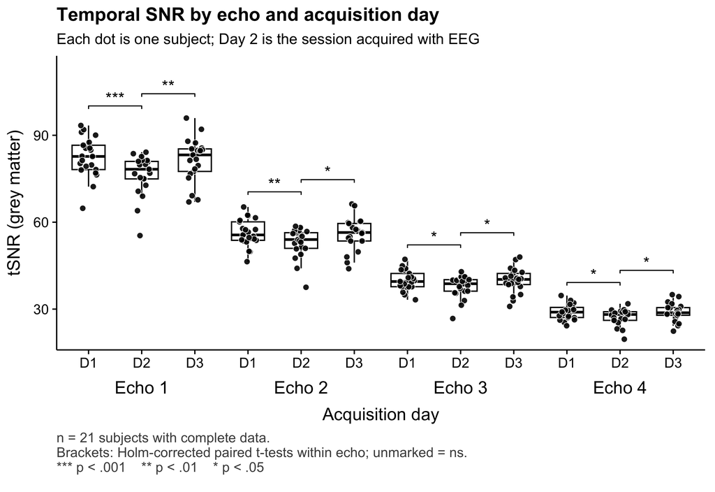

```r
p_tsnr <- tsnr_panel(
  tsnr_rm,
  pw       = day_by_echo,
  title    = "Temporal SNR by echo and acquisition day",
  subtitle = "Each dot is one subject; Day 2 is the session acquired with EEG",
  x_title  = "Acquisition day",
  caption  = paste0(
    "n = ", n_distinct(tsnr_rm$ID), " subjects with complete data.\n",
    "Brackets: Holm-corrected paired t-tests within echo; unmarked = ns.\n",
    "*** p < .001    ** p < .01    * p < .05"
  ),
  short = \(s) sub("^Day ", "D", s)
)

p_tsnr
```

### Size of the day differences, per echo

The interaction is easier to read as a proportion, because tSNR itself differs by a factor of three across echoes.

```r
pct_day <- tsnr_rm |>
  group_by(echo, day) |>
  summarise(mean = mean(tSNR), .groups = "drop") |>
  pivot_wider(names_from = day, values_from = mean) |>
  mutate(
    `Day 2 vs Day 1 (%)` = 100 * (`Day 2` - `Day 1`) / `Day 1`,
    `Day 3 vs Day 1 (%)` = 100 * (`Day 3` - `Day 1`) / `Day 1`
  )

pct_day |>
  mutate(across(where(is.numeric), ~ round(.x, 2)))
```

| echo | Day 1 | Day 2 | Day 3 | Day 2 vs Day 1 (%) | Day 3 vs Day 1 (%) |
| --- | --- | --- | --- | --- | --- |
| 1 | 82.34 | 76.39 | 81.46 | -7.23 | -1.07 |
| 2 | 56.26 | 52.96 | 55.95 | -5.87 | -0.55 |
| 3 | 39.91 | 37.76 | 39.87 | -5.38 | -0.08 |
| 4 | 28.97 | 27.31 | 28.96 | -5.72 | -0.04 |

### Is the interaction just a scaling effect?

An equal *proportional* change across echoes would still show up as an interaction in absolute units, since echo 1 has three times the tSNR of echo 4. Refitting on `log(tSNR)` turns proportional effects into additive ones, so if the interaction is purely a scaling artefact it disappears here.

```r
fit_log <- tsnr_rm |>
  mutate(log_tSNR = log(tSNR)) |>
  anova_test(dv = log_tSNR, wid = ID, within = c(day, echo))

get_anova_table(fit_log, correction = "auto")
```

|  | Effect | DFn | DFd | F | p | p<.05 | ges |
| --- | --- | --- | --- | --- | --- | --- | --- |
| 1 | day | 2.00 | 40.00 | 6.113 | 5.00e-03 | * | 0.081000 |
| 2 | echo | 1.23 | 24.65 | 15244.158 | 7.77e-37 | * | 0.940000 |
| 3 | day:echo | 1.84 | 36.74 | 2.505 | 1.00e-01 |  | 0.000962 |

# Part 2: within Day 2 (runs 2-5)

All four runs of the Day 2 session were acquired with the EEG cap in place. If the cap, or cap-related drift (gel drying, subject settling, heating), degraded tSNR progressively, it should show up as a run effect here.

```r
runs_d2   <- 2:5
run_labels <- paste("Rest", runs_d2)

tsnr_d2_all <- tsnr_long |>
  filter(run %in% runs_d2) |>
  mutate(
    run_f = factor(run, levels = runs_d2, labels = run_labels),
    scan  = droplevels(scan),
    echo  = droplevels(echo)
  )

n_cells_d2 <- length(runs_d2) * nlevels(tsnr_d2_all$echo)

tsnr_d2 <- tsnr_d2_all |>
  group_by(ID) |>
  filter(dplyr::n() == n_cells_d2) |>
  ungroup() |>
  mutate(ID = factor(ID), grp = run_f) |>
  add_cells()

cat(
  "Complete cases: ", n_distinct(tsnr_d2$ID), " of ",
  n_distinct(tsnr_d2_all$ID), " subjects with any Day 2 run\n", sep = ""
)
```

```
## Complete cases: 24 of 24 subjects with any Day 2 run
```

```r
tsnr_d2_all |>
  group_by(ID) |>
  filter(dplyr::n() < n_cells_d2) |>
  summarise(runs_present = paste(sort(unique(run)), collapse = ", "), .groups = "drop")
```

| ID | runs_present |
| --- | --- |

## Summary statistics

```r
tsnr_d2 |>
  group_by(echo, run_f) |>
  summarise(
    n      = dplyr::n(),
    mean   = mean(tSNR),
    sd     = sd(tSNR),
    median = median(tSNR),
    IQR    = IQR(tSNR),
    min    = min(tSNR),
    max    = max(tSNR),
    .groups = "drop"
  ) |>
  mutate(across(mean:max, ~ round(.x, 2)))
```

| echo | run_f | n | mean | sd | median | IQR | min | max |
| --- | --- | --- | --- | --- | --- | --- | --- | --- |
| 1 | Rest 2 | 24 | 76.31 | 7.19 | 79.05 | 6.67 | 55.38 | 84.16 |
| 1 | Rest 3 | 24 | 73.77 | 6.82 | 74.86 | 8.90 | 59.70 | 85.64 |
| 1 | Rest 4 | 24 | 75.91 | 6.42 | 78.37 | 9.02 | 61.64 | 85.40 |
| 1 | Rest 5 | 24 | 76.50 | 7.14 | 77.90 | 8.70 | 57.71 | 88.14 |
| 2 | Rest 2 | 24 | 52.99 | 5.33 | 54.56 | 5.54 | 37.54 | 58.99 |
| 2 | Rest 3 | 24 | 51.11 | 5.00 | 51.08 | 7.18 | 42.60 | 59.53 |
| 2 | Rest 4 | 24 | 52.74 | 4.82 | 54.02 | 7.42 | 42.23 | 59.02 |
| 2 | Rest 5 | 24 | 53.08 | 5.15 | 54.32 | 5.62 | 40.53 | 61.55 |
| 3 | Rest 2 | 24 | 37.82 | 3.99 | 39.17 | 4.35 | 26.75 | 42.98 |
| 3 | Rest 3 | 24 | 36.42 | 3.80 | 36.61 | 5.04 | 29.90 | 42.56 |

[output cut: 6 more lines]

## Two-way repeated-measures ANOVA

**run** (4 levels: rest2-rest5) and **echo** (4 levels) are both within-subject. Same model as Part 1, with run in place of day.

```r
fit_d2 <- anova_test(tsnr_d2, dv = tSNR, wid = ID, within = c(run_f, echo))

get_anova_table(fit_d2, correction = "auto")
```

|  | Effect | DFn | DFd | F | p | p<.05 | ges |
| --- | --- | --- | --- | --- | --- | --- | --- |
| 1 | run_f | 3.00 | 69.00 | 1.964 | 1.27e-01 |  | 0.023 |
| 2 | echo | 1.06 | 24.31 | 4064.516 | 8.28e-29 | * | 0.935 |
| 3 | run_f:echo | 2.31 | 53.15 | 1.710 | 1.86e-01 |  | 0.003 |

Sphericity:

```r
fit_d2$`Mauchly's Test for Sphericity`
```

|  | Effect | W | p | p<.05 |
| --- | --- | --- | --- | --- |
| 1 | run_f | 7.21e-01 | 2.14e-01 |  |
| 2 | echo | 8.94e-04 | 7.46e-31 | * |
| 3 | run_f:echo | 2.83e-13 | 1.16e-91 | * |

```r
fit_d2$`Sphericity Corrections`
```

| Effect | GGe | DF[GG] | p[GG] | p[GG]<.05 | HFe | DF[HF] | p[HF] | p[HF]<.05 |
| --- | --- | --- | --- | --- | --- | --- | --- | --- |
| run_f | 0.826 | 2.48, 57.01 | 1.40e-01 |  | 0.934 | 2.8, 64.43 | 1.32e-01 |  |
| echo | 0.352 | 1.06, 24.31 | 8.28e-29 | * | 0.355 | 1.06, 24.49 | 5.24e-29 | * |
| run_f:echo | 0.257 | 2.31, 53.15 | 1.86e-01 |  | 0.287 | 2.58, 59.44 | 1.81e-01 |  |

### Marginal means

```r
tsnr_d2 |>
  group_by(run_f) |>
  summarise(mean = round(mean(tSNR), 2), sd = round(sd(tSNR), 2), .groups = "drop")
```

| run_f | mean | sd |
| --- | --- | --- |
| Rest 2 | 48.62 | 19.17 |
| Rest 3 | 46.91 | 18.55 |
| Rest 4 | 48.41 | 18.92 |
| Rest 5 | 48.71 | 19.20 |

```r
tsnr_d2 |>
  group_by(echo) |>
  summarise(mean = round(mean(tSNR), 2), sd = round(sd(tSNR), 2), .groups = "drop")
```

| echo | mean | sd |
| --- | --- | --- |
| 1 | 75.62 | 6.88 |
| 2 | 52.48 | 5.06 |
| 3 | 37.45 | 3.81 |
| 4 | 27.10 | 2.80 |

### Post-hoc comparisons

Reported for completeness even though the omnibus run effect is not significant, so they should be read as descriptive rather than confirmatory. Subject means across echoes for the main-effect follow-up, as in Part 1.

```r
tsnr_d2 |>
  group_by(ID, run_f) |>
  summarise(tSNR = mean(tSNR), .groups = "drop") |>
  pairwise_t_test(tSNR ~ run_f, paired = TRUE, p.adjust.method = "holm") |>
  select(group1, group2, statistic, df, p, p.adj, p.adj.signif)
```

| group1 | group2 | statistic | df | p | p.adj | p.adj.signif |
| --- | --- | --- | --- | --- | --- | --- |
| Rest 2 | Rest 3 | 1.7726759 | 23 | 0.090 | 0.358 | ns |
| Rest 2 | Rest 4 | 0.2117777 | 23 | 0.834 | 1.000 | ns |
| Rest 2 | Rest 5 | -0.1006262 | 23 | 0.921 | 1.000 | ns |
| Rest 3 | Rest 4 | -2.3602384 | 23 | 0.027 | 0.163 | ns |
| Rest 3 | Rest 5 | -2.2544252 | 23 | 0.034 | 0.170 | ns |
| Rest 4 | Rest 5 | -0.4229371 | 23 | 0.676 | 1.000 | ns |

Within each echo — these are the comparisons annotated on the Day 2 figure:

```r
run_by_echo <- tsnr_d2 |>
  group_by(echo) |>
  pairwise_t_test(tSNR ~ run_f, paired = TRUE, p.adjust.method = "holm")

run_by_echo |>
  select(echo, group1, group2, statistic, df, p, p.adj, p.adj.signif)
```

| echo | group1 | group2 | statistic | df | p | p.adj | p.adj.signif |
| --- | --- | --- | --- | --- | --- | --- | --- |
| 1 | Rest 2 | Rest 3 | 1.70160091 | 23 | 0.102 | 0.408 | ns |
| 1 | Rest 2 | Rest 4 | 0.26227184 | 23 | 0.795 | 1.000 | ns |
| 1 | Rest 2 | Rest 5 | -0.13501137 | 23 | 0.894 | 1.000 | ns |
| 1 | Rest 3 | Rest 4 | -2.47756842 | 23 | 0.021 | 0.126 | ns |
| 1 | Rest 3 | Rest 5 | -2.26582481 | 23 | 0.033 | 0.166 | ns |
| 1 | Rest 4 | Rest 5 | -0.52859480 | 23 | 0.602 | 1.000 | ns |
| 2 | Rest 2 | Rest 3 | 1.79086162 | 23 | 0.086 | 0.346 | ns |
| 2 | Rest 2 | Rest 4 | 0.21823373 | 23 | 0.829 | 1.000 | ns |
| 2 | Rest 2 | Rest 5 | -0.09660201 | 23 | 0.924 | 1.000 | ns |
| 2 | Rest 3 | Rest 4 | -2.28803172 | 23 | 0.032 | 0.190 | ns |

[output cut: 14 more lines]

```
## Within-echo run comparisons surviving Holm correction: 0 of 24
```

## Plot

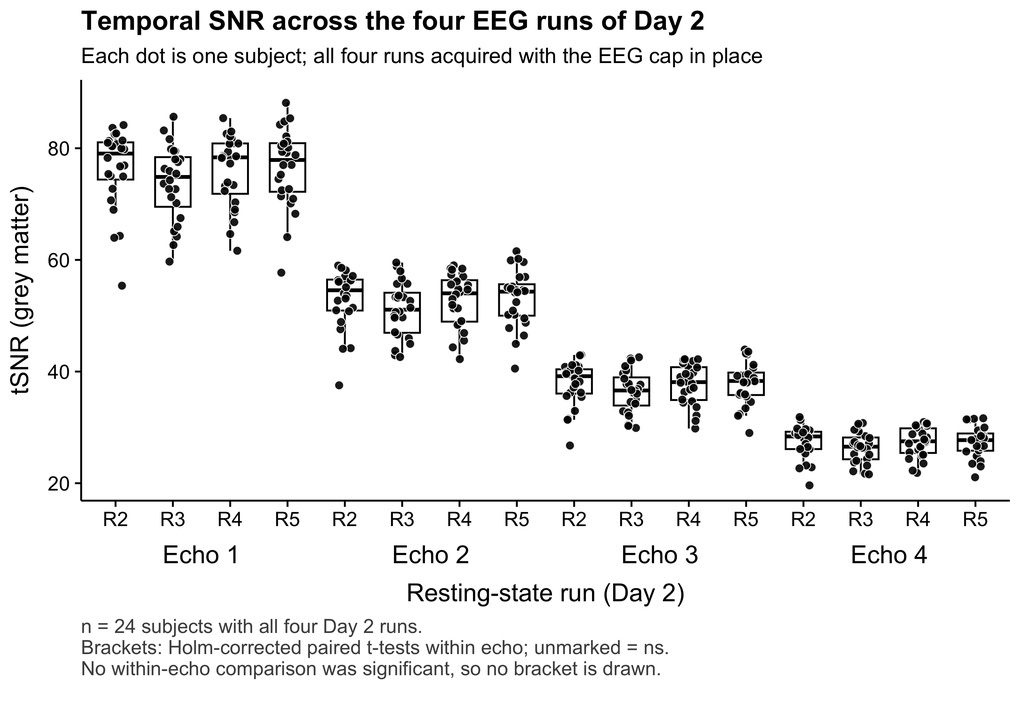

```r
p_d2 <- tsnr_panel(
  tsnr_d2,
  pw       = run_by_echo,
  title    = "Temporal SNR across the four EEG runs of Day 2",
  subtitle = "Each dot is one subject; all four runs acquired with the EEG cap in place",
  x_title  = "Resting-state run (Day 2)",
  caption  = paste0(
    "n = ", n_distinct(tsnr_d2$ID), " subjects with all four Day 2 runs.\n",
    "Brackets: Holm-corrected paired t-tests within echo; unmarked = ns.\n",
    if (n_sig_d2 == 0) "No within-echo comparison was significant, so no bracket is drawn."
    else "*** p < .001    ** p < .01    * p < .05"
  ),
  short = \(s) sub("^Rest ", "R", s)
)

p_d2
```

### Size of the run differences, per echo

Relative to rest2, the first EEG run of the session.

```r
pct_d2 <- tsnr_d2 |>
  group_by(echo, run_f) |>
  summarise(mean = mean(tSNR), .groups = "drop") |>
  pivot_wider(names_from = run_f, values_from = mean) |>
  mutate(
    `Rest 3 vs Rest 2 (%)` = 100 * (`Rest 3` - `Rest 2`) / `Rest 2`,
    `Rest 4 vs Rest 2 (%)` = 100 * (`Rest 4` - `Rest 2`) / `Rest 2`,
    `Rest 5 vs Rest 2 (%)` = 100 * (`Rest 5` - `Rest 2`) / `Rest 2`
  )

pct_d2 |>
  mutate(across(where(is.numeric), ~ round(.x, 2)))
```

| echo | Rest 2 | Rest 3 | Rest 4 | Rest 5 | Rest 3 vs Rest 2 (%) | Rest 4 vs Rest 2 (%) | Rest 5 vs Rest 2 (%) |
| --- | --- | --- | --- | --- | --- | --- | --- |
| 1 | 76.31 | 73.77 | 75.91 | 76.50 | -3.33 | -0.53 | 0.25 |
| 2 | 52.99 | 51.11 | 52.74 | 53.08 | -3.54 | -0.46 | 0.19 |
| 3 | 37.82 | 36.42 | 37.68 | 37.88 | -3.70 | -0.37 | 0.15 |
| 4 | 27.37 | 26.34 | 27.30 | 27.40 | -3.78 | -0.26 | 0.10 |

### Log check

```r
tsnr_d2 |>
  mutate(log_tSNR = log(tSNR)) |>
  anova_test(dv = log_tSNR, wid = ID, within = c(run_f, echo)) |>
  get_anova_table(correction = "auto")
```

|  | Effect | DFn | DFd | F | p | p<.05 | ges |
| --- | --- | --- | --- | --- | --- | --- | --- |
| 1 | run_f | 3.00 | 69.00 | 1.76 | 1.63e-01 |  | 2.40e-02 |
| 2 | echo | 1.17 | 26.88 | 17625.73 | 3.67e-40 | * | 9.36e-01 |
| 3 | run_f:echo | 2.65 | 60.92 | 0.76 | 5.06e-01 |  | 9.37e-05 |

# Summary of observed effects

**Echo dominates.** tSNR falls monotonically with echo number — 80.1 (echo 1), 55.1, 39.2, and 28.4 (echo 4) — a very large effect (*F*(1.07, 21.31) = 3427.9, *p* < .001, ges = 0.94). This is the expected T2* decay: later echoes have longer TE, so less signal remains while thermal noise stays roughly constant. It is a property of the sequence, not a data-quality finding.

**Day 2 loses about 6% of its tSNR.** Collapsed across echoes, mean tSNR is 51.9 (Day 1), 48.6 (Day 2) and 51.6 (Day 3): *F*(2, 40) = 6.8, *p* = 0.003, ges = 0.083. The post-hoc pattern is unambiguous: Day 1 > Day 2 and Day 3 > Day 2 both survive correction, while Day 1 vs Day 3 is nowhere near significance (*p* = 0.78). Day 2 is the EEG session and the only session that differs; the two non-EEG days are statistically indistinguishable, differing by at most 1.1% in any echo. The loss is present in **every** echo (all 8 Day-2 contrasts in the figure survive Holm correction), and the magnitude is stable: 5.4% to 7.2% across the four echoes.

**The day x echo interaction is a scaling artefact.** In absolute units it is significant (*F*(2.16, 43.16) = 11.71, *p* < .001, ges = 0.021), but on the log scale it drops to *F*(1.84, 36.74) = 2.5, *p* = 0.100, ges = 9.6^{-4} — not significant. So the effect is a constant *proportional* loss on Day 2, which looks like an interaction only because echo 1 sits on a three-times-larger scale. That is the signature of a multiplicative signal loss (or a noise gain) affecting all echoes equally, consistent with the EEG cap and its leads rather than with anything TE-specific.

**The EEG penalty does not drift within the session.** Across the four Day 2 runs, mean tSNR is 48.6 (rest2), 46.9, 48.4 and 48.7 (rest5): *F*(3, 69) = 1.96, *p* = 0.127, ges = 0.023, and the run x echo interaction is also null (*p* = 0.186, ges = 0.003). 0 of 24 within-echo run comparisons survive correction, which is why the Day 2 figure carries no brackets. Rest3 is nominally the lowest run (about 3.6% below rest2 in every echo), but it does not survive correction and rest4 and rest5 return to the rest2 level, so this is noise rather than a trend.

Taken together: the cost is attached to *having the cap on*, not to how long it has been on. It appears at full size in the first EEG run and stays flat for the rest of the session.

**Practical consequences.** Pooling resting-state runs across days is no longer safe without accounting for session: a systematic 6% tSNR difference between the EEG day and the two non-EEG days will propagate into any between-session comparison of effect sizes or variance. Include session as a covariate, or restrict within-subject contrasts to runs from the same day. Echo weighting for the multi-echo combination, on the other hand, *can* use the same weights on each day — the loss is proportional across echoes, so the relative weighting is unchanged.

## Does averaging tSNR over voxels make sense?

Partly. What is being analysed here is one number per subject, run and echo: the mean of the voxelwise tSNR map inside that subject’s grey-matter mask (`fslstats -k … -M` in `eeg_fmri_ext_SNR_2_v2.sh`). For the question actually being asked — *is image quality stable across sessions, and how does it scale with echo?* — that is the right summary. It is a single scalar per cell, so the repeated-measures ANOVA above is exactly the correct test, it has real power at n = 21, and restricting to grey matter already avoids the main artefact of whole-brain averaging (ventricles and edge voxels dragging the mean around).

The averaging does, however, hide the things most likely to matter:

- **tSNR is strongly spatially non-uniform.** It is high in the cortex and low in orbitofrontal and inferior temporal regions, where susceptibility dropout is worst. A stable global mean is compatible with a real loss confined to those regions.
- **The global mean cannot localise the Day 2 loss.** A uniform 6% drop in the GM mean is equally consistent with a uniform 6% drop everywhere and with a much larger loss confined to electrode-adjacent cortex, offset by unchanged deep voxels. Those two possibilities have very different implications for whether task activation on Day 2 is comparable to the other days.
- **The mean is not where the optimal echo weighting lives.** Optimal T2* weighting is voxelwise, since T2* varies regionally; a global mean per echo cannot inform it.

## Does a voxel-wise analysis make sense?

Yes, and now it is the obvious next step rather than an optional complement. Part 1 establishes *that* Day 2 costs tSNR; the maps already exist (`*_bold_tSNR_masked.nii.gz`), so answering *where* is cheap. The sensible route is to normalise each subject’s tSNR maps to a common template, then fit the same day x echo model voxelwise (SPM flexible factorial, or FSL randomise for a non-parametric test), with cluster- or TFCE-based correction.

The specific hypothesis worth testing is spatial: if the loss is caused by the cap, it should be largest in superficial cortex near the electrodes and smallest in deep and central structures. A small set of *a priori* ROIs — an occipital/electrode-adjacent ROI, a dropout-prone orbitofrontal ROI, and a deep/central ROI — analysed with the same day x echo model, tests that directly at a fraction of the correction burden of a whole-brain search. A full voxelwise map is then best used descriptively, to show the spatial distribution of the Day 2 loss.